# Auxilliary analysis: Mean network

Mariella Gregorich

07 April, 2022

# 1 Background

## 1.1 Data-generating design

Individual-specific networks are constructed based on the principle that partial correlations between random variables can be obtained through the inversion of the covariance matrix (precision matrix) and taking the ratio of appropriate entries from the precision matrix. It follow the study by Xie et al. (2020).

Each individual-specific precision matrix $\Omega_i(r,s)$ is currently constructed based on a transformed $p\times p$-dimensional scale-free mean-structered matrix $\alpha_0$, where $p$ denotes the number of nodes. The mean-structured matrix indicates the default connections between pairs of nodes and is thus the same for all individuals $i=1,..,n$.

The mean-structure is derived from the Barabasi-Albert model, a stochastic algorithm for scale-free network construction, such that a matrix is obtained with binary entries indicating the presence of a connection with 1 and the absence with 0. The entries of $\alpha_0$ corresponding tHE presence of a connection are $\alpha_0(r,s)\sim N(0,1) , r, s=1,...,p$. The individual variability is introduced by two individual-specific latent variables $(X_{1i},X_{2i})$ and two $p \times p$-dimensional weight matrices $\alpha_1$ and $\alpha_2$ representing the edge-specific effect of the latent variables on the default structure.

Individual-specific entries $\alpha_i(r,s)$ for each node pair $(r,s)$ are then obtained by
$$\begin{equation}
\tag{1}
A_i(r,s) = \alpha_0(r,s) + \alpha_1(r,s)X_{1i} + \alpha_2(r,s)X_{2i},
\end{equation}$$
where $\alpha_1$ and $\alpha_2$ are drawn from a uniform distribution $U(0,1)$. The final precision matrix $\Omega_i(r,s)$ is obtained by a transformation $f(.)$, which transforms $A_i\rightarrow (0,1)$ into a beta distribution $Beta(a,b)$ with predefined scaling factors $a$ and $b$.

The partial correlation between node $s$ and $r$ defining the pairwise edge weight for individual $i$ is then constructed through the definition of partial correlation:
$$\begin{equation}
\tag{2}
w_i(r,s):=\rho_i(s,r)=-\frac{\Omega_i(s,r)}{\sqrt(\Omega_i(s,s)\Omega_i(r,r))}
\end{equation}$$
The diagonal elements of $\Omega_i$ are set to 1 in $\Omega_i$ such that $\rho_i(r,s) \in [0,1]$.

Table 1.1: Parameters for the data-generating mechanism

| Terms | Values |
| --- | --- |
| Sample size | 250 |
| Nodes | 50 |
| Possible edges | 1225 |
| Latent processes | 2 |
| Density of the mean network | 84.49 |

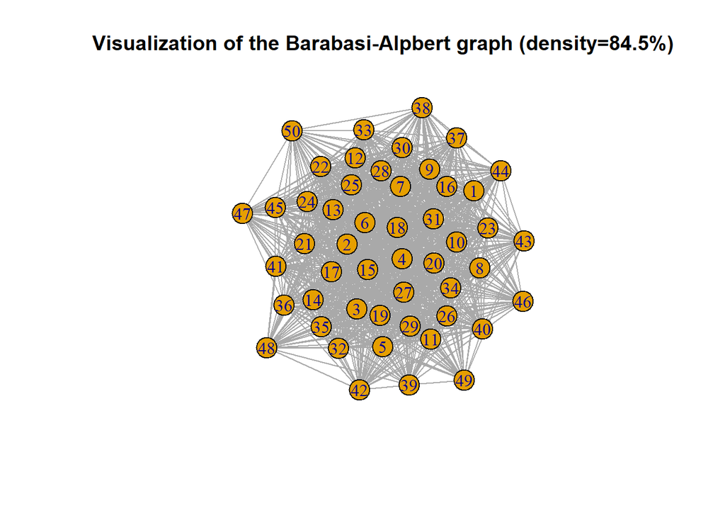

## 1.2 Thresholding

In the following we will differentiate between sparsification and thresholding as follows: Sparsification will describe the methodology to reduce the network density either by a

- weight-based approach
- density-based approach while thresholding describes the methodology of how retained edge weights are transformed either by
- Weight trimming
  $$\begin{equation}
  \tilde{w}_{rs}=
  \begin{cases}
  w_{rs}, & \text{if}\ w_{rs} > \tau \\
  0, & \text{otherwise}
  \end{cases}
  \end{equation}$$
- Weight binarization
  $$\begin{equation}
  \tilde{w}_{rs}=
  \begin{cases}
  1, & \text{if}\ w_{rs} > \tau \\
  0, & \text{otherwise}
  \end{cases}
  \end{equation}$$
- Weight reshaping
  $$\begin{equation}
  \tilde{w}_{rs}=
  \begin{cases}
  w_{rs}-\tau, & \text{if}\ w_{rs} > \tau \\
  0, & \text{otherwise}
  \end{cases}
  \end{equation}$$

## 1.3 Graph-theoretical features

The following graph-theoretical features will be examined:

[output not shown]

# 2 Default-structure Network

## 2.1 Visualization

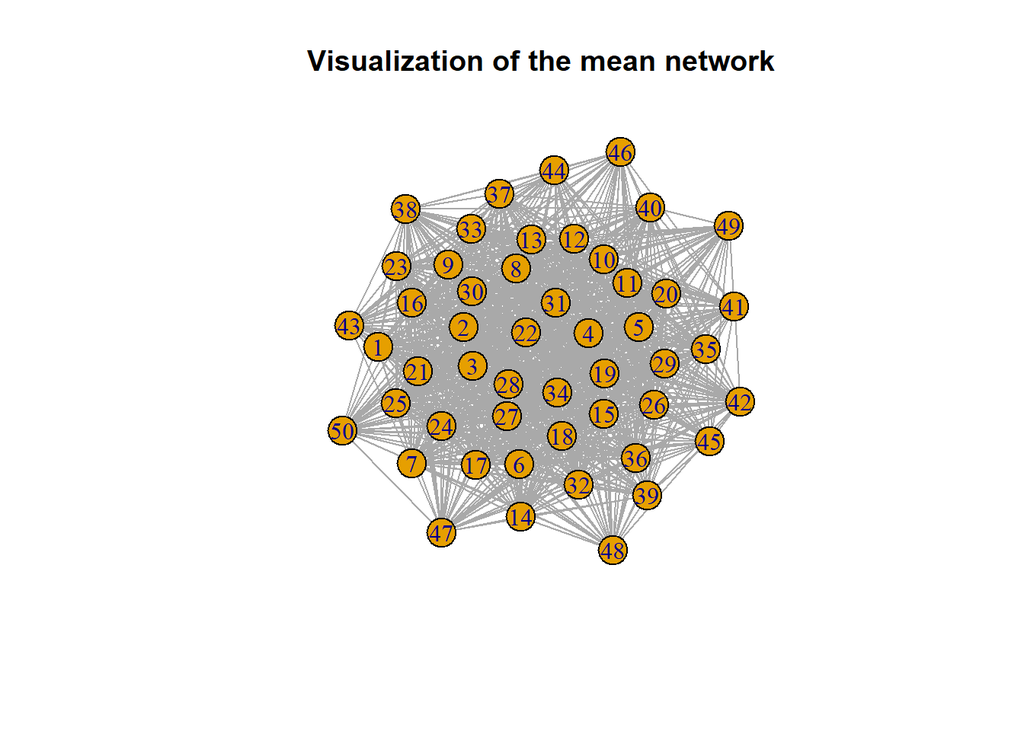

## 2.2 Edge weight distribution

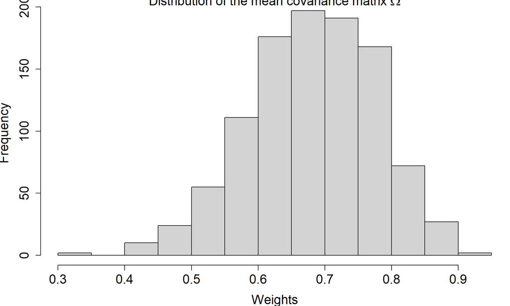

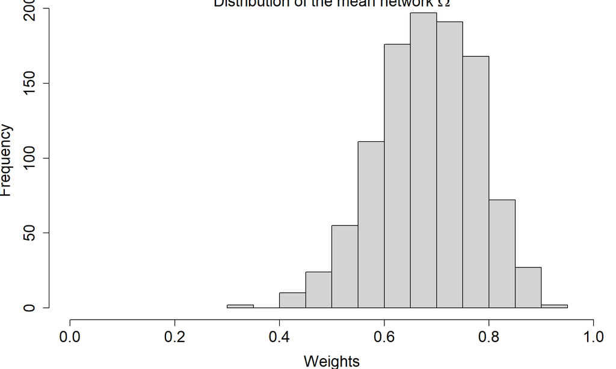

Figure 2.1: Histogram of the edge weight components (omega1, omega2) of mnet excluding zero entries

## 2.3 Thresholding and graph-theoretical features

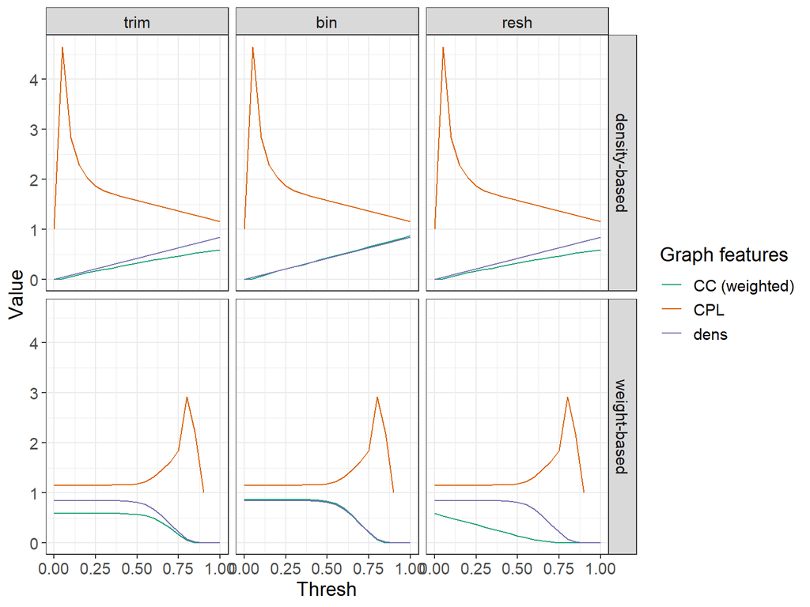

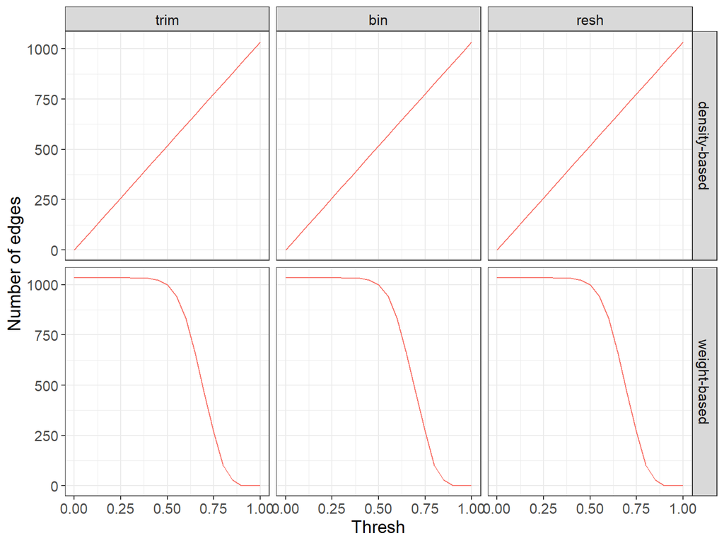

Figure 2.3: Number of edges per approach

# 3 Individual-specific networks

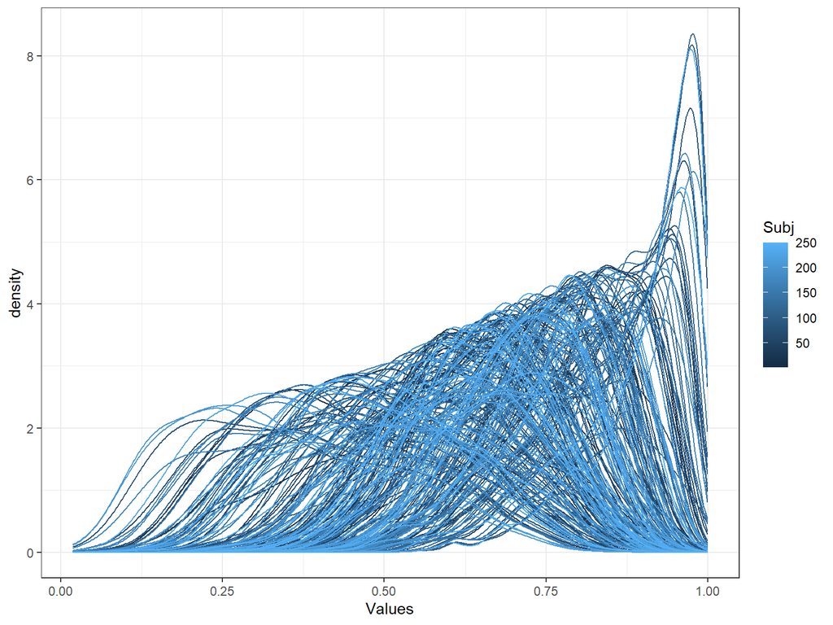

Figure 3.1: Individual-specific variability of edge weights due to the latent processes

## 3.1 Weight-based thresholding

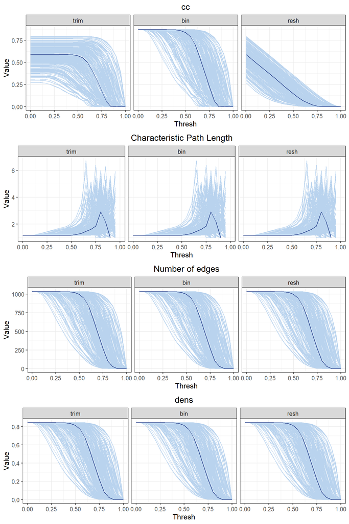

## 3.2 Density-based thresholding

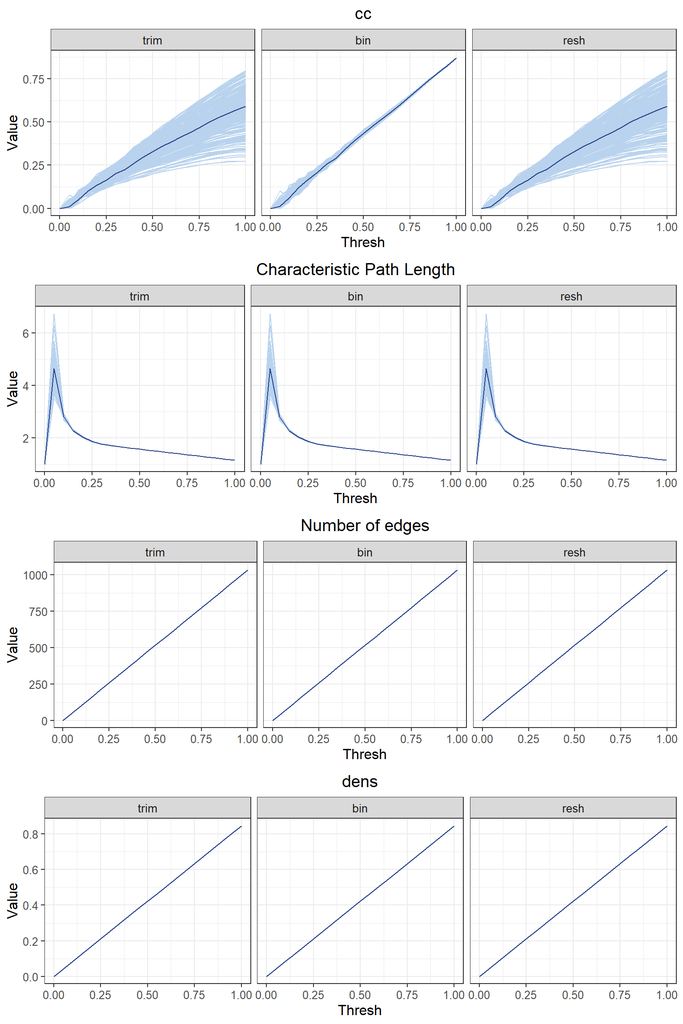

# 4 References

Xie, Shanghong, Xiang Li, Peter McColgan, Rachael I Scahill, Donglin Zeng, and Yuanjia Wang. 2020. “Identifying Disease-Associated Biomarker Network Features Through Conditional Graphical Model.” *Biometrics* 76 (3): 995–1006.